# Module 2: Introduction to Bayesian Statistics

## Choosing different models: DIC

- So far we have met a wide array of discrete-time time series models, all of which involve choose a \(p\) (AR component), a \(q\) (MA component), and a \(d\) (differencing component)
- We need a principled method to choose the best values of these. It will always be the case that increasing these values will lead to a better fit
- There are several proposed methods for doing this:
  1. Treat the model as another parameter (Bayes factors and reversible jump)
  2. Remove some of the data and predict the left out data (Cross-validation)
  3. Use statistical theory to penalise the fit of the model (Information Criteria)
- All of these are good and useful, but number 3 is implemented by JAGS for us to use

## Measuring model complexity

- You may have met many other types of information criteria, e.g. the Akaike (AIC) or Bayesian (BIC, not really Bayesian)
- These work by adding on a function of the number of parameters, designed to approximate some performance criterion (e.g. out of sample performance for AIC)
- This isn't quite so simple in the Bayesian world as the number of parameters, in the presence of prior information, can be hard to estimate
- The version JAGS uses is known as the Deviance Information Criterion (DIC) and is built specifically to penalise the deviance by the *effective* number of parameters, which it calls \(p_D\)

## The components of DIC

- JAGS provides the DIC whenever we call the `print` command on a model run

```r
DIC info (using the rule, pD = var(deviance)/2)
pD = 6.9 and DIC = -261.1
```

- Here \(p_D\) estimates the effective number of parameters in the model and the DIC is calculated as the deviance plus the \(p_D\) value
- The usual practice is to run models of differing complexity (e.g. with differing values of \(p\), \(d\), and \(q\)) and choose the model with the lowest DIC

## Seasonal time series

- So far we haven't covered how to deal with data that are *seasonal* in nature
- These data generally fall into two categories:
  1. Data where we know the frequency or frequencies (e.g. monthly data on a yearly cycle, frequency = 12)
  2. Data where we want to esitmate the frequencies (e.g. climate time series, animal populations, etc)
- The former are much simpler, as we can e.g. use month as a covariate in an ARIMAX model, perform a seasonal difference with an ARIMA, or fit a full seasonal ARIMA model (though the JAGS code for this gets complicated)
- The latter are much more interesting. The ACF and PACF can help, but we can usually do much better by creating a *power spectrum*

## Methods for estimating frequencies

- The most common way to estimate the frequencies in a time series is to decompose it in a *Fourier Series*
- We write:\[ y_t = \alpha + \sum_{k=1}^K \left[ \beta_k \sin (2 \pi f_k) + \gamma_k \cos (2 \pi f_k) \right] + \epsilon_t\]
- Each one of the terms inside the sum is called a *harmonic*. We decompose the series into a sum of sine and cosine waves rather than with AR and MA components
- Each sine/cosine pair has its own frequency \(f_k\). If the corresponding coefficients \(\beta_k\) and \(\gamma_k\) are large we might believe this frequency is important

## Estimating frequencies via a Fourier model

- It's certainly possible to fit the model in the previous slide in JAGS, as it's just a linear regression model with clever explanatory variables
- However, it can be quite slow to fit and, if the number of frequencies \(K\) is high, or the frequencies are close together, it can struggle to converge
- More commonly, people repeatedly fit the simpler model:\[ y_t = \alpha + \beta \sin (2 \pi f_k) + \gamma \cos (2 \pi f_k) + \epsilon_t\]for lots of different values of \(f_k\). Then calculate the *power spectrum* as \(P(f_k) = \frac{\beta^2 + \gamma^2}{2}\). Large values of the power spectrum indicate important frequencies
- It's much faster to do this outside of JAGS, using other methods, but we will stick to JAGS

## JAGS code for a Fourier model

```r
model_code = '
model
{
  # Likelihood
  for (t in 1:T) {
    y[t] ~ dnorm(mu[t], tau)
    mu[t] <- alpha + beta * cos( 2 * pi * t * f_k ) + gamma * sin( 2 * pi * t * f_k )
  }
  P = ( pow(beta, 2) + pow(gamma, 2) ) / 2

  # Priors
  alpha ~ dnorm(0.0,0.01)
  beta ~ dnorm(0.0,0.01)
  gamma ~ dnorm(0.0,0.01)
  tau <- 1/pow(sigma,2) # Turn precision into standard deviation
  sigma ~ dunif(0.0,100.0)
}
'
```

## Example: the Lynx data

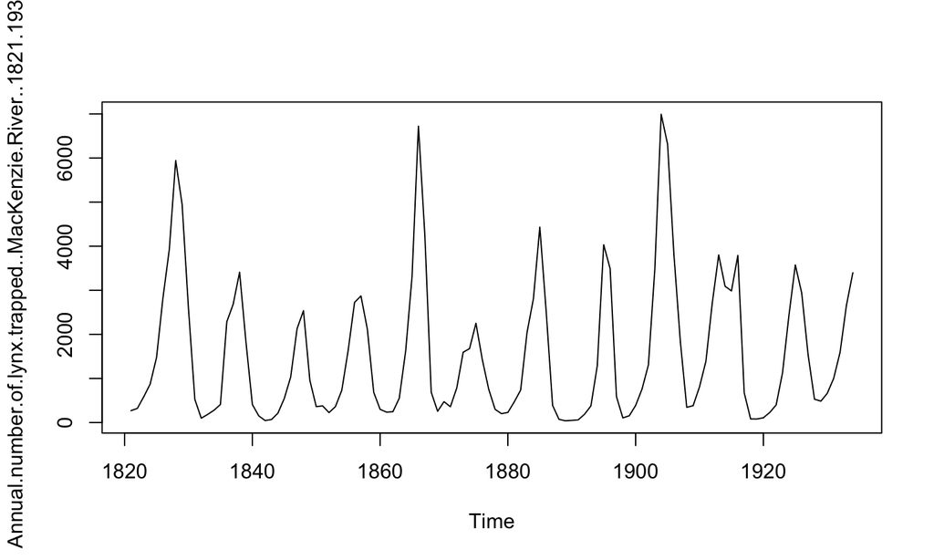

```r
lynx = as.ts(dmseries('http://data.is/Ky69xY'))
plot(lynx)
```

## Code to run the JAGS model repeatedly

```r
periods = 5:40
K = length(periods)
f = 1/periods
Power = rep(NA,K)
model_parameters =  c("P")

for (k in 1:K) {
  curr_model_data = list(y = as.vector(lynx[,1]),
                         T = length(lynx),
                         f_k = f[k],
                         pi = pi)

  model_run = jags(data = curr_model_data,
                   parameters.to.save = model_parameters,
                   model.file=textConnection(model_code),
                   n.chains=4,
                   n.iter=1000,
                   n.burnin=200,
                   n.thin=2)

  Power[k] = mean(model_run$BUGSoutput$sims.list$P)
}
```

## Plotting the periodogram

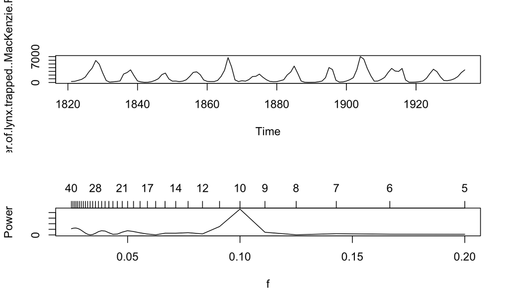

```r
par(mfrow = c(2, 1))
plot(lynx)
plot(f, Power, type='l')
axis(side = 3, at = f, labels = periods)
```

## Bayesian vs traditional frequency analysis

- For quick and dirty analysis, there is no need to run the full Bayesian model, the R function `periodogram` in the TSA package will do the job
- However, the big advantage (as always with Bayes) is that we can also plot the uncertainty in the periodogram, or combine the Fourier model with other modelling ideas (e.g. ARIMA)
- There are much fancier versions of frequency models out there (e.g. Wavelets, or frequency selection models) which can also be fitted in JAGS but require a bit more time and effort
- These Fourier models work for continuous time series too

## Summary

- We now know how to incorporate explanatory variables in ARIMA models (and we also know the pitfalls of doing so)
- We know how to compare models using DIC and the basis behind penalised deviance
- We understand how to estimate frequencies using a power spectrum calculated in JAGS